# Multiple Linear Regression: First Order and Second Order

Alison Pedraza

2024-04-10

### Project Purpose, Contents, and Data Sources:

**Purpose**

- To use First and Second order Multiple Linear Regression on chronic disease indicator data and Covid data to predict total Covid deaths.

**Contents:**

- Download of two separate data sets, scrub and clean each.
- Join both data sets and prepare data for regression.
- Exploratory Data Analysis (EDA) on final data frame
- Multiple Linear Regression:
  - First order full model
  - First order reduced model
  - Transformed model using Box-Cox transformation
  - Second order model
- Study of Residuals and other Diagnostics
- General Linear Test approach used on full and reduced model.
- Predict total Covid deaths using all four models

**The Data:**

- Chronic Disease Indicators data set:
  - Disease Indicators data comes from Data.gov, U.S. Department of Health & Human Services, and Centers of Disease Control and Prevention.
  - Full dataset name: **U.S. Chronic Disease Indicators**
  - URL link: **https://catalog.data.gov/dataset/u-s-chronic-disease-indicators-cdi**
  - The full data set is offered on the above website.
  - Since the original data set has 124 indicators and very large, a subset of the original dataset was used for the purposes of this analysis exercise.
- Covid Data:
  - From Kaggle Website : **https://www.kaggle.com/datasets/imdevskp/corona-virus-report**
  - Dataset is from year 2020.
  - Contains data at the county and state level.

### Data Collection and Preparation:

- Chronic Disease Indicator Data:

```r
DI_df <- read.csv("Disease_Indicators_data.csv")

DI_df2<- DI_df%>%dplyr::select("County", "Percent.of.population.aged.18.34", "Percent.of.population.65.or.older", "Number.of.active.physicians","Number.of.hospital.beds", "Total.serious.crimes" , "Percent.high.school.graduates", "Percent.bachelor.s.degrees", "Percent.below.poverty.level" , "Percent.unemployment",  "Total.personal.income", "Geographic.region")

colnames(DI_df2) <- c("county", "Percent_population_aged_18_34","Percent_population_65_older","Number_active._physicians","Number_hospital_beds", "Total_serious_crimes" , "Percent_highschool_graduates","Percent_bachelor_degrees","Percent_below_poverty_level" , "Percent_unemployment",  "Total_personal_income", "Geographic_region")

DI_df2$NE <- I(DI_df2$Geographic_region=="1")*1
DI_df2$MW <- I(DI_df2$Geographic_region=="2")*1
DI_df2$STH <- I(DI_df2$Geographic_region=="3")*1
DI_df2$WST <- I(DI_df2$Geographic_region=="4")*1

# Remove the '_' character from the county names in the  'county' column :
DI_df2$county<-gsub("_"," ",as.character(DI_df2$county))
```

- Covid Data

```r
covid_df <- read.csv("covid_data.csv")

# select columns
covid_A<- covid_df%>%dplyr::select( "county", "state" ,  "fips" ,"cases"  ,  "deaths", "stay_at_home_announced", "stay_at_home_effective" ,  "total_population","area_sqmi" ,"population_density_per_sqmi","num_deaths", "years_of_potential_life_lost_rate", "percent_smokers" ,"percent_adults_with_obesity" ,"food_environment_index", "income_ratio" , "percent_physically_i0ctive" , "percent_uninsured" ,"num_primary_care_physicians" )


# Group by county and state - with MAX COVID CASES AND COVID DEATHS
covid_B <- covid_A%>%group_by(county, state, fips, total_population, population_density_per_sqmi,  years_of_potential_life_lost_rate,percent_smokers,percent_adults_with_obesity,
              food_environment_index,income_ratio,percent_physically_i0ctive,percent_uninsured,
              num_primary_care_physicians)%>%summarise(total_covid_cases = max(cases), total_covid_deaths = max(deaths))

colnames(covid_B)[11] <- "Percent_physically_inactive"

covid_B[is.na(covid_B)] = 0 # Replace NA with 0
```

#### Final Data Frame

```r
# Join the two data frames by County since what have in common
df2 <- left_join(covid_B, DI_df2, by = c("county"))   # Using Max Covid cases and Covid deaths

# Using Max deaths and Max Covid Cases
df2 <- df2%>%drop_na(Percent_population_aged_18_34,  Percent_population_65_older, Number_active._physicians, Number_hospital_beds ,Total_serious_crimes, Percent_highschool_graduates ,Percent_bachelor_degrees ,Percent_below_poverty_level, Percent_unemployment,Total_personal_income)

df2$total_covid_deaths <- replace(df2$total_covid_deaths, df2$total_covid_deaths == 0, 0.01)


kbl(head(df2)) %>%
  kable_styling(bootstrap_options = c("striped", "hover", "condensed"))
```

| county | state | fips | total_population | population_density_per_sqmi | years_of_potential_life_lost_rate | percent_smokers | percent_adults_with_obesity | food_environment_index | income_ratio | Percent_physically_inactive | percent_uninsured | num_primary_care_physicians | total_covid_cases | total_covid_deaths | Percent_population_aged_18_34 | Percent_population_65_older | Number_active._physicians | Number_hospital_beds | Total_serious_crimes | Percent_highschool_graduates | Percent_bachelor_degrees | Percent_below_poverty_level | Percent_unemployment | Total_personal_income | Geographic_region | NE | MW | STH | WST |
| --- | --- | --- | --- | --- | --- | --- | --- | --- | --- | --- | --- | --- | --- | --- | --- | --- | --- | --- | --- | --- | --- | --- | --- | --- | --- | --- | --- | --- | --- |
| Ada | Idaho | 16001 | 425798 | 404.551458 | 5088.378 | 11.99070 | 25.6 | 8.1 | 4.478032 | 14.9 | 8.743292 | 428 | 18698 | 191 | 27.6 | 10.4 | 367 | 557 | 9701 | 87.2 | 24.9 | 6.2 | 4.1 | 3866 | 4 | 0 | 0 | 0 | 1 |
| Adams | Colorado | 8001 | 479977 | 411.188748 | 6436.698 | 16.32461 | 27.8 | 8.7 | 3.725936 | 19.9 | 11.026551 | 219 | 17503 | 270 | 29.6 | 7.6 | 439 | 318 | 19369 | 78.8 | 13.0 | 8.8 | 5.0 | 4271 | 4 | 0 | 0 | 0 | 1 |
| Adams | Idaho | 16003 | 3865 | 2.836063 | 0.000 | 14.35193 | 30.5 | 7.6 | 3.681277 | 21.2 | 14.383095 | 1 | 80 | 2 | 29.6 | 7.6 | 439 | 318 | 19369 | 78.8 | 13.0 | 8.8 | 5.0 | 4271 | 4 | 0 | 0 | 0 | 1 |
| Adams | Illinois | 17001 | 66949 | 78.284133 | 7087.094 | 15.45719 | 36.6 | 8.3 | 4.225536 | 27.6 | 5.236587 | 59 | 2726 | 30 | 29.6 | 7.6 | 439 | 318 | 19369 | 78.8 | 13.0 | 8.8 | 5.0 | 4271 | 4 | 0 | 0 | 0 | 1 |
| Adams | Indiana | 18001 | 34813 | 102.684660 | 7299.512 | 20.45444 | 34.8 | 8.1 | 3.819934 | 30.4 | 11.623897 | 13 | 823 | 11 | 29.6 | 7.6 | 439 | 318 | 19369 | 78.8 | 13.0 | 8.8 | 5.0 | 4271 | 4 | 0 | 0 | 0 | 1 |
| Adams | Iowa | 19003 | 3822 | 9.026107 | 0.000 | 15.63671 | 29.9 | 8.7 | 3.532057 | 24.7 | 6.194375 | 1 | 93 | 1 | 29.6 | 7.6 | 439 | 318 | 19369 | 78.8 | 13.0 | 8.8 | 5.0 | 4271 | 4 | 0 | 0 | 0 | 1 |

### Exploratory Data Analysis

##### Density Plots

- The density plot shows the distribution of total covid deaths at the county level
- In the states selected, total population for each county and total deaths from Covid are not different. This could suggest that counties with high total population will have high total Covid deaths.

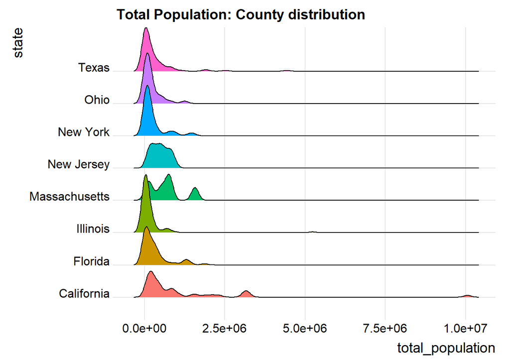

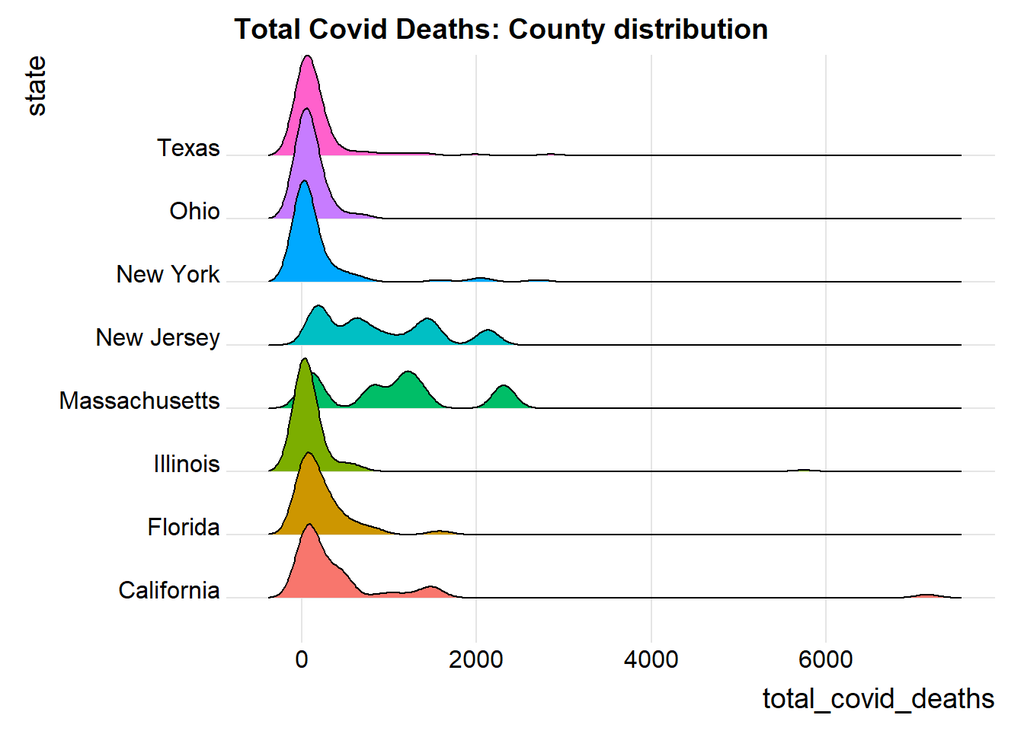

##### Histogram of Total Covid Deaths:

- **Total covid deaths** is not very normally distributed. It is slightly left skewed. This may affect the distribution of errors as well.
- **Total Covid Cases** is more normally distributed.

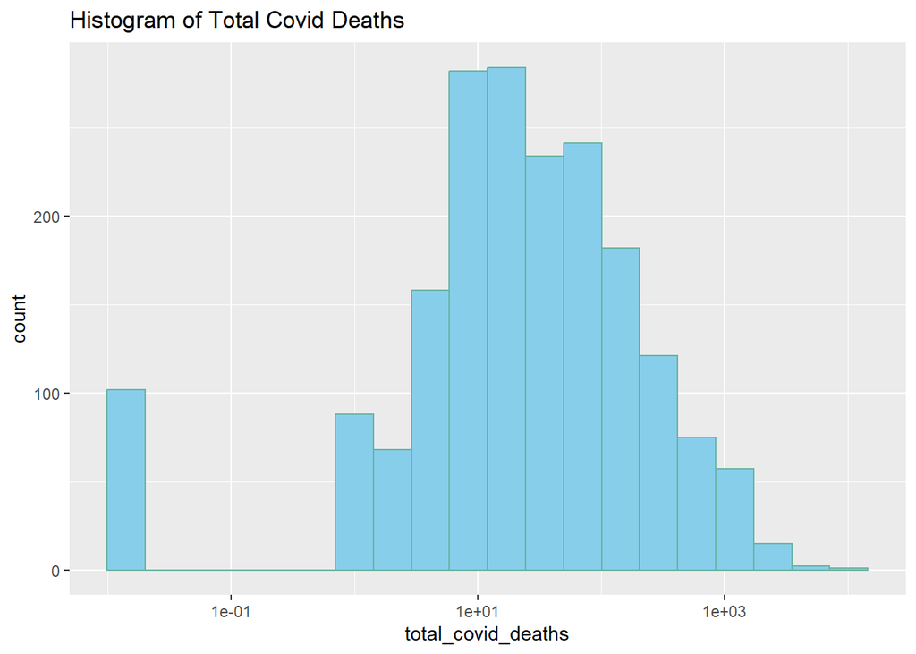

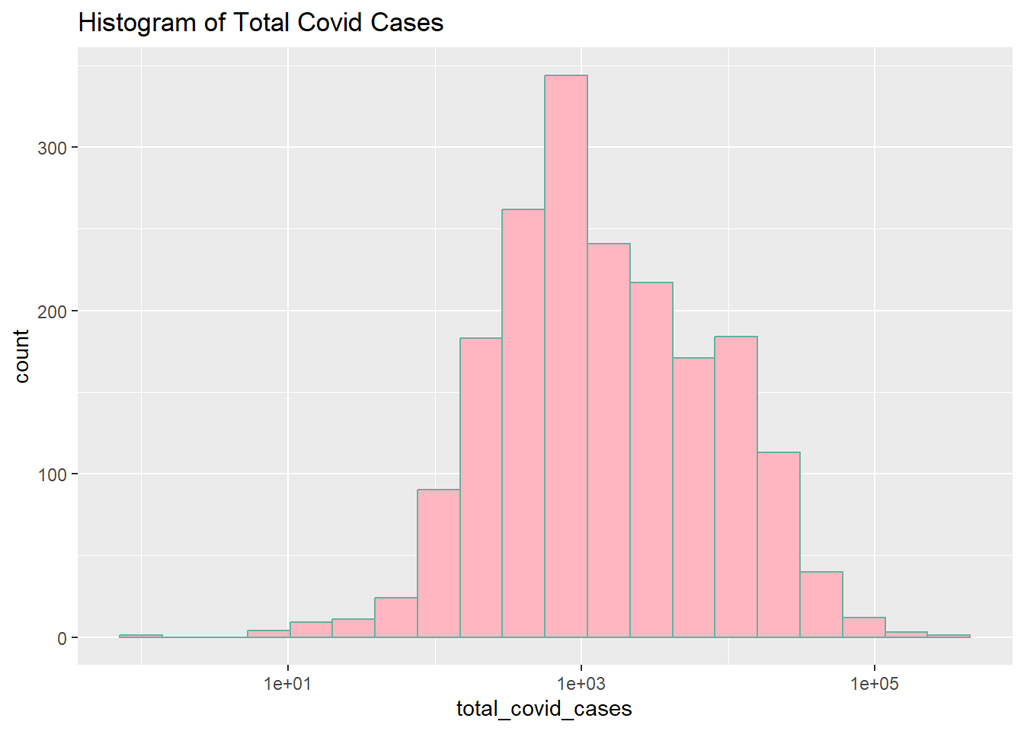

##### Scatter Plots:

- There does not seem to be an obvious linear relationship between **total covid deaths** and many of the predictors.
- There is a funnel shape to the observations with the predictors **total serious crimes**, **number of active physicians**, and **total population**.

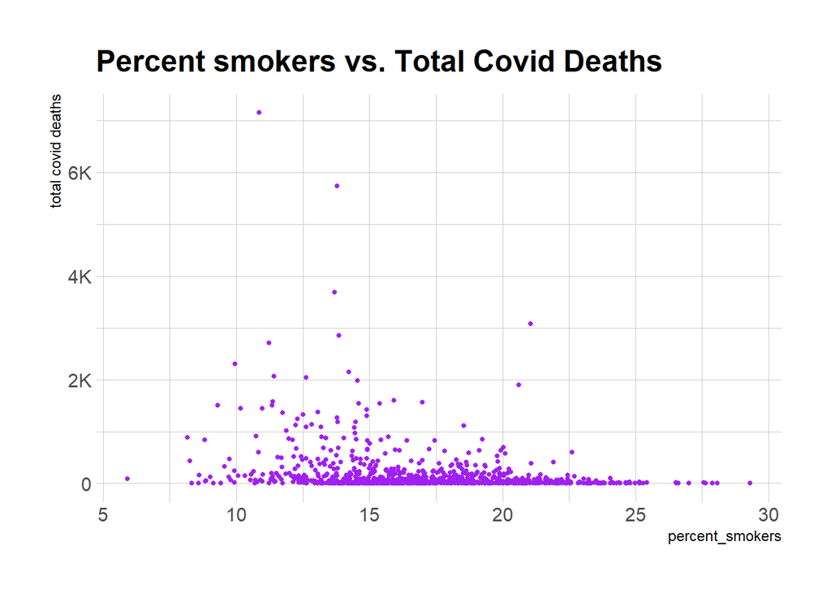

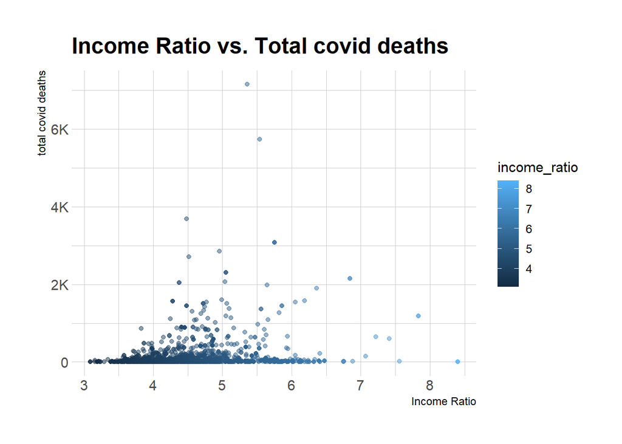

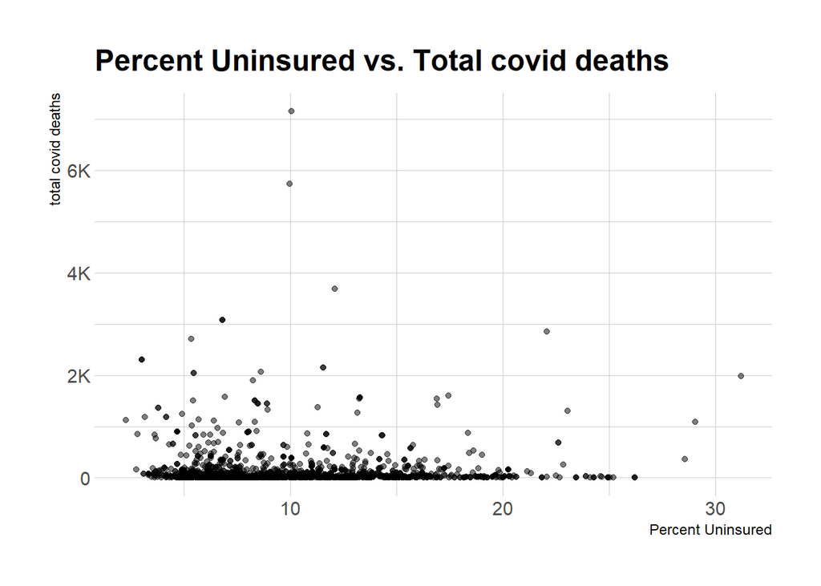

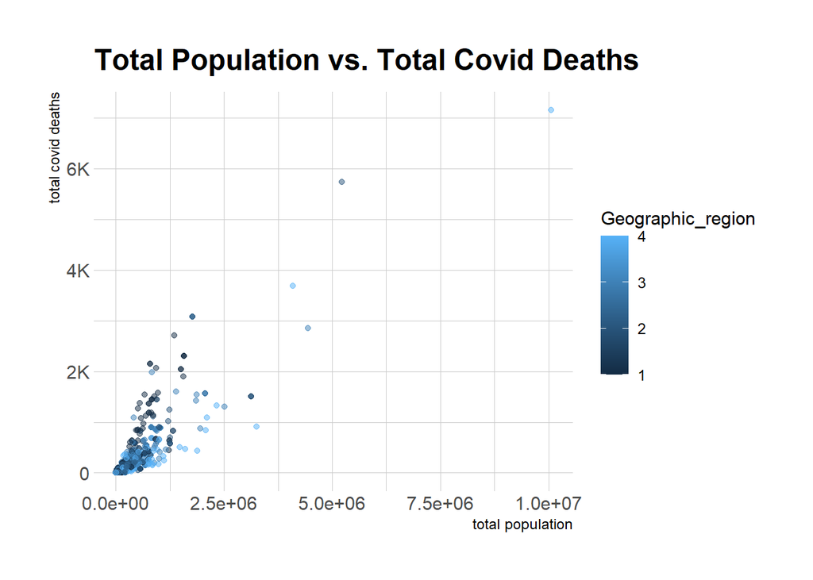

[figure not shown]

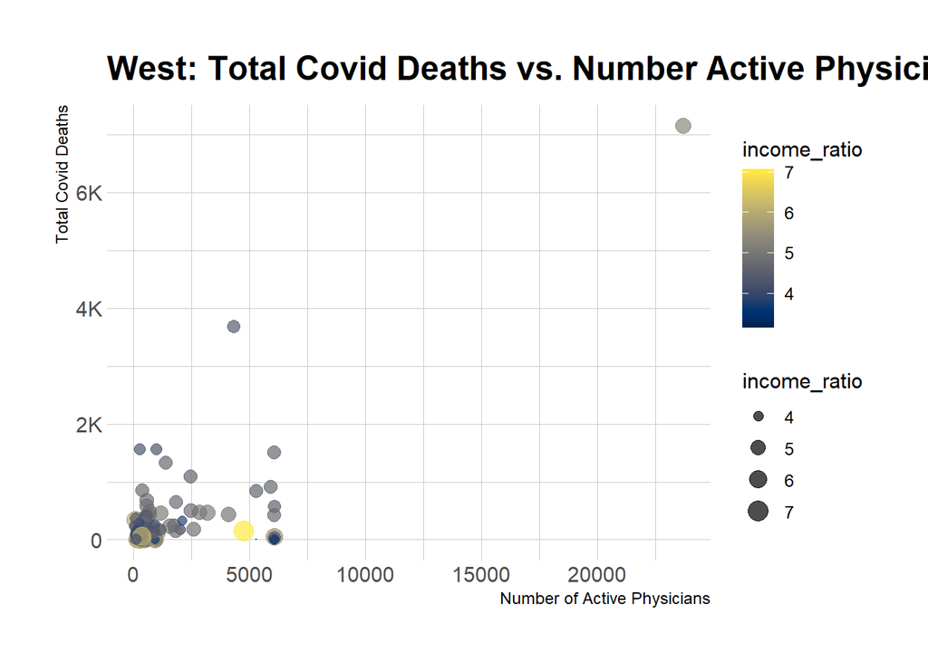

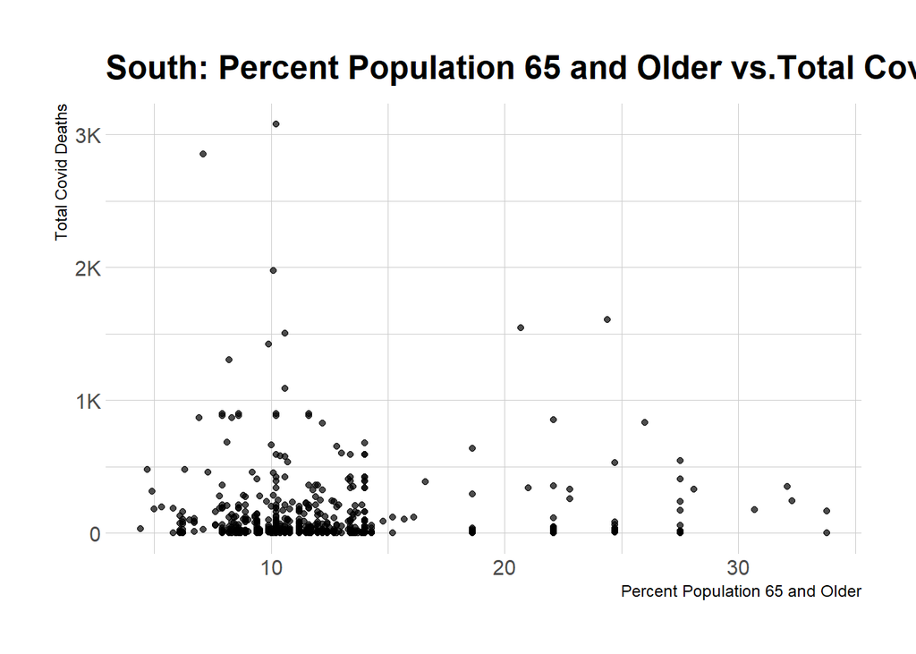

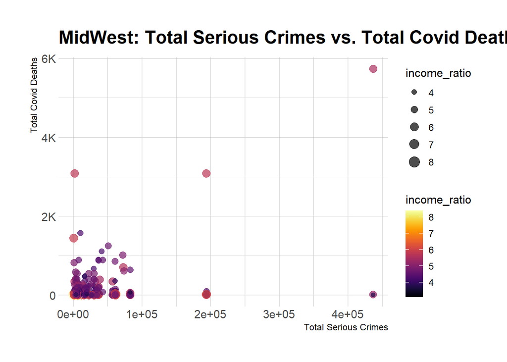

[figure not shown]

### Split Data: Test and Train Split

```r
set.seed(123)
n <- dim(df2)[1]

new_df <- df2[, -c(1, 2, 3, 26)]
indices <- sample(1:n, 0.7*n)
train_df <- new_df[indices, ]
test_df <- new_df[-indices,]
```

### First Order Multiple Linear Regression

- For this first order multiple linear regression, **state** and **county** and **fips** will not be used since dummy variables for Geographic Region will be used instead. (Geographic region Dummy Variables: NE, STH, WST, MW)
  - state
  - Geographic_region
  - county
  - fips
- Summary shows:
  - Residual Standard Error = 145.9
  - Adjusted $R^2$ = 0.8408
  - F-statistic = 295.1

```r
options("scipen"=10)
multi_reg_full <- lm(total_covid_deaths ~. , data = train_df )
summary(multi_reg_full)
```

```
##
## Call:
## lm(formula = total_covid_deaths ~ ., data = train_df)
##
## Residuals:
##     Min      1Q  Median      3Q     Max
## -825.98  -42.41    0.72   37.84 1797.47
##
## Coefficients: (1 not defined because of singularities)
##                                        Estimate    Std. Error t value
## (Intercept)                       -358.34061952  145.03375259  -2.471
## total_population                     0.00021827    0.00006229   3.504
## population_density_per_sqmi          0.08409557    0.00708149  11.875
## years_of_potential_life_lost_rate   -0.00114883    0.00228592  -0.503
## percent_smokers                     -5.65515866    1.90955968  -2.961
## percent_adults_with_obesity         -0.45283990    1.05163727  -0.431
## food_environment_index              15.96423670    4.69689889   3.399
## income_ratio                        25.04675583    7.45675267   3.359
## Percent_physically_inactive          6.83084585    1.07734580   6.340
## percent_uninsured                   -0.40855468    1.05218049  -0.388
## num_primary_care_physicians          0.12052934    0.05070709   2.377
## total_covid_cases                    0.01053600    0.00114233   9.223
## Percent_population_aged_18_34       -1.75476783    1.43751189  -1.221
## Percent_population_65_older          1.37250226    1.51725274   0.905
## Number_active._physicians           -0.00663949    0.01206788  -0.550
## Number_hospital_beds                -0.00511980    0.00755801  -0.677
## Total_serious_crimes                -0.00083479    0.00023257  -3.589
## Percent_highschool_graduates        -1.17388537    1.39158036  -0.844
## Percent_bachelor_degrees             2.24522363    1.11691741   2.010
## Percent_below_poverty_level          4.34995689    1.78453263   2.438
## Percent_unemployment                 8.67971717    2.78717510   3.114
## Total_personal_income                0.00635333    0.00169736   3.743
## NE                                  58.34787575   17.67040485   3.302
## MW                                  32.00757564   15.31492160   2.090
## STH                                 12.54058136   16.11689652   0.778
## WST                                          NA            NA      NA
##                                         Pr(>|t|)
## (Intercept)                             0.013610 *
## total_population                        0.000474 ***
## population_density_per_sqmi              < 2e-16 ***
```

[output cut: 14 more lines]

```
## Percent_highschool_graduates            0.399068
## Percent_bachelor_degrees                0.044615 *
## Percent_below_poverty_level             0.014918 *
## Percent_unemployment                    0.001885 **
## Total_personal_income                   0.000190 ***
## NE                                      0.000986 ***
## MW                                      0.036814 *
## STH                                     0.436649
## WST                                           NA
## ---
## Signif. codes:  0 '***' 0.001 '**' 0.01 '*' 0.05 '.' 0.1 ' ' 1
##
## Residual standard error: 145.9 on 1312 degrees of freedom
## Multiple R-squared:  0.8437, Adjusted R-squared:  0.8408
## F-statistic: 295.1 on 24 and 1312 DF,  p-value: < 2.2e-16
```

### Study of Residuals and Other Diagnostics for First Order Full Model

#### Plots: First Order Full Model

- Time plot of residuals:
  - There is no obvious pattern in the time plot.

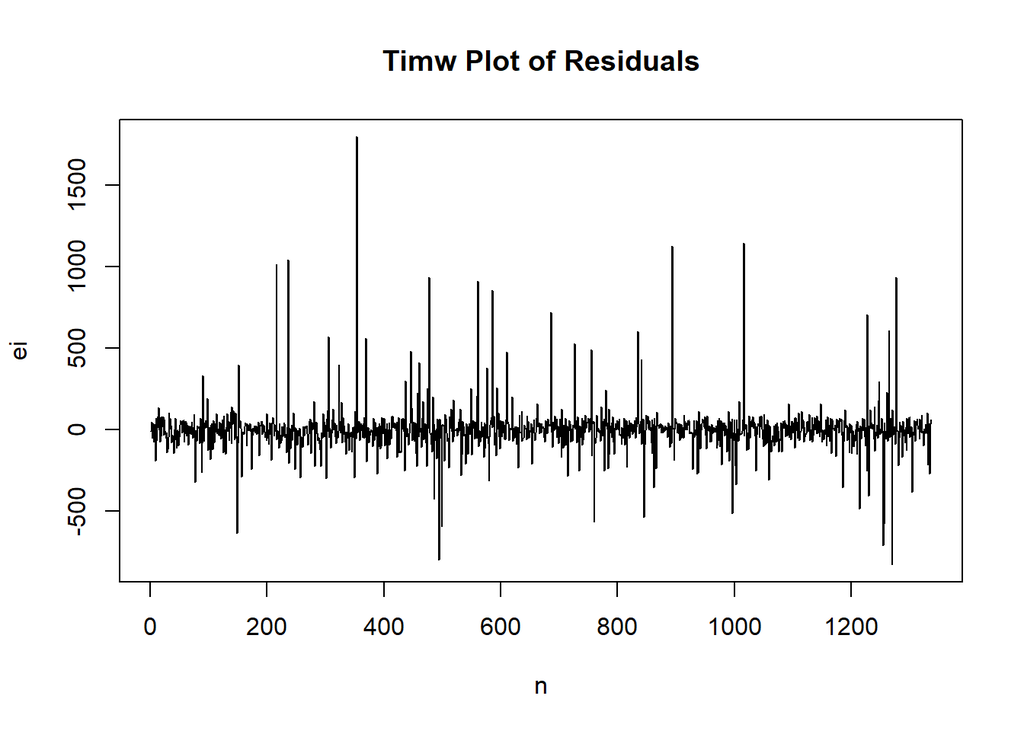

- Additional Plots to check regression assumptions:
  - Funnel shape for residuals. They are not constant.
  - Some outliers are present as seen in Residual-Leverage plot:
    - observations: 149, 1255, 594

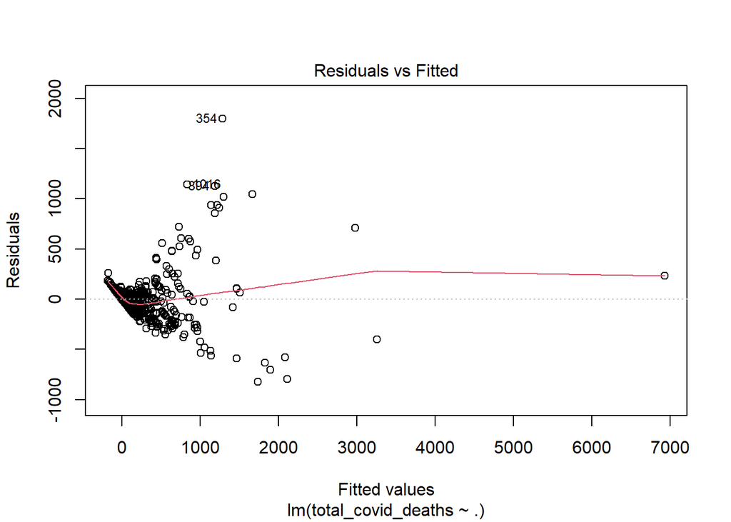

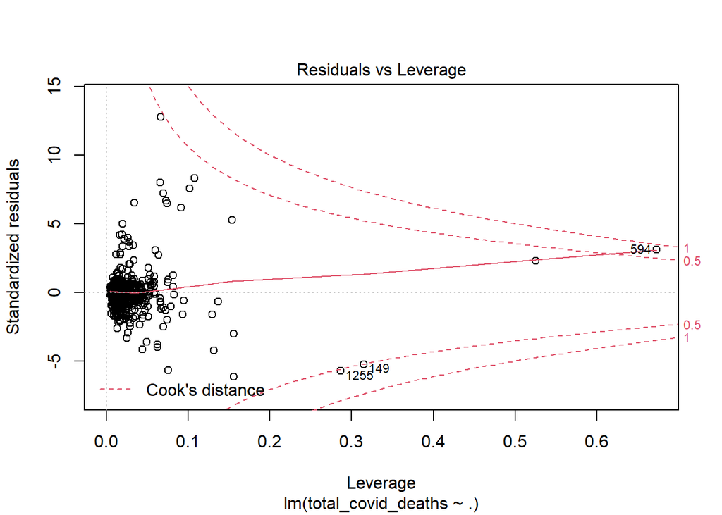

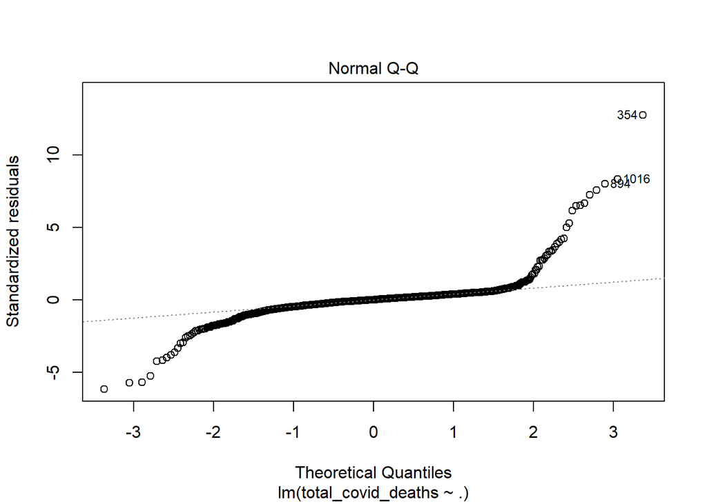

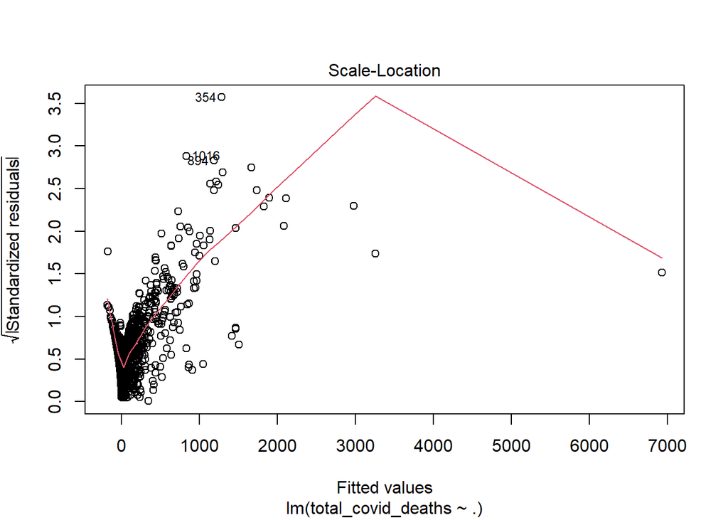

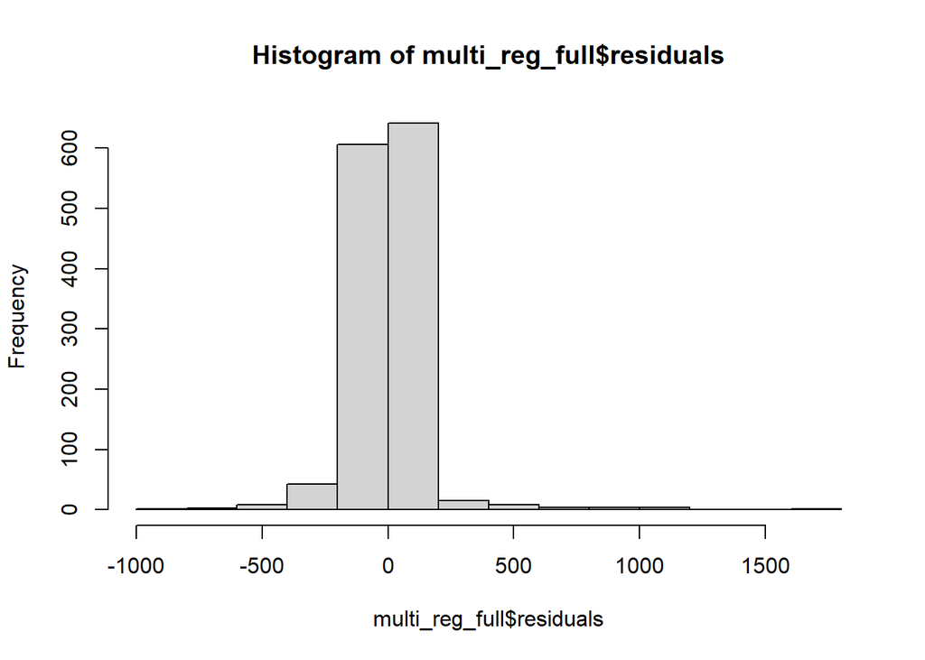

#### ANOVA Table

- Analysis of the Variance for each predictor shows that the following features have the highest F-score in this model:
  - Total population
  - population density per sqr mile
  - Total covid cases
  - percent physical inactivity

```r
options("scipen"=10)
anova(multi_reg_full)
```

```
## Analysis of Variance Table
##
## Response: total_covid_deaths
##                                     Df    Sum Sq   Mean Sq   F value    Pr(>F)
## total_population                     1 138344239 138344239 6501.0112 < 2.2e-16
## population_density_per_sqmi          1   6506461   6506461  305.7487 < 2.2e-16
## years_of_potential_life_lost_rate    1     30421     30421    1.4295  0.232061
## percent_smokers                      1      7846      7846    0.3687  0.543824
## percent_adults_with_obesity          1    140665    140665    6.6101  0.010250
## food_environment_index               1     48849     48849    2.2955  0.129990
## income_ratio                         1    554457    554457   26.0548 3.807e-07
## Percent_physically_inactive          1   1440500   1440500   67.6913 4.560e-16
## percent_uninsured                    1     36332     36332    1.7073  0.191567
## num_primary_care_physicians          1     14728     14728    0.6921  0.405608
## total_covid_cases                    1   1561963   1561963   73.3991 < 2.2e-16
## Percent_population_aged_18_34        1    143274    143274    6.7327  0.009572
## Percent_population_65_older          1    152986    152986    7.1891  0.007427
## Number_active._physicians            1    225513    225513   10.5972  0.001161
## Number_hospital_beds                 1     44721     44721    2.1015  0.147395
## Total_serious_crimes                 1    126065    126065    5.9240  0.015069
## Percent_highschool_graduates         1    147734    147734    6.9423  0.008517
## Percent_bachelor_degrees             1     10584     10584    0.4973  0.480794
## Percent_below_poverty_level          1       126       126    0.0059  0.938763
## Percent_unemployment                 1    573736    573736   26.9608 2.404e-07
## Total_personal_income                1    261773    261773   12.3011  0.000468
## NE                                   1    226091    226091   10.6244  0.001145
## MW                                   1    103058    103058    4.8428  0.027935
## STH                                  1     12884     12884    0.6054  0.436649
## Residuals                         1312  27919909     21280
##
## total_population                  ***
## population_density_per_sqmi       ***
## years_of_potential_life_lost_rate
## percent_smokers
## percent_adults_with_obesity       *
## food_environment_index
## income_ratio                      ***
## Percent_physically_inactive       ***
## percent_uninsured
## num_primary_care_physicians
## total_covid_cases                 ***
## Percent_population_aged_18_34     **
## Percent_population_65_older       **
## Number_active._physicians         **
## Number_hospital_beds
## Total_serious_crimes              *
## Percent_highschool_graduates      **
## Percent_bachelor_degrees
## Percent_below_poverty_level
## Percent_unemployment              ***
## Total_personal_income             ***
## NE                                **
## MW                                *
## STH
## Residuals
## ---
## Signif. codes:  0 '***' 0.001 '**' 0.01 '*' 0.05 '.' 0.1 ' ' 1
```

### General Linear Test Approach

#### Reduced Model: Multiple First Order Regression model using only the following variables:

```r
multi_reg_red <- lm(total_covid_deaths ~ total_population + population_density_per_sqmi +years_of_potential_life_lost_rate    +  years_of_potential_life_lost_rate  + income_ratio + Percent_physically_inactive + Total_serious_crimes +  Percent_below_poverty_level  +   Percent_unemployment + Total_personal_income + NE + MW , data = train_df)
summary(multi_reg_red)
```

```
##
## Call:
## lm(formula = total_covid_deaths ~ total_population + population_density_per_sqmi +
##     years_of_potential_life_lost_rate + years_of_potential_life_lost_rate +
##     income_ratio + Percent_physically_inactive + Total_serious_crimes +
##     Percent_below_poverty_level + Percent_unemployment + Total_personal_income +
##     NE + MW, data = train_df)
##
## Residuals:
##      Min       1Q   Median       3Q      Max
## -1265.77   -38.22     2.38    37.38  1617.80
##
## Coefficients:
##                                        Estimate    Std. Error t value
## (Intercept)                       -322.61251477   34.82394932  -9.264
## total_population                     0.00064757    0.00001262  51.330
## population_density_per_sqmi          0.09743751    0.00648922  15.015
## years_of_potential_life_lost_rate   -0.00652514    0.00201440  -3.239
## income_ratio                        18.48022163    7.10799426   2.600
## Percent_physically_inactive          6.08019740    0.93136831   6.528
## Total_serious_crimes                -0.00091299    0.00021190  -4.309
## Percent_below_poverty_level          3.41258505    1.34957217   2.529
## Percent_unemployment                 7.84559659    2.30705017   3.401
## Total_personal_income                0.00515327    0.00092341   5.581
## NE                                  44.75296914   12.35442618   3.622
## MW                                  11.33119659    9.89152854   1.146
##                                          Pr(>|t|)
## (Intercept)                               < 2e-16 ***
## total_population                          < 2e-16 ***
## population_density_per_sqmi               < 2e-16 ***
## years_of_potential_life_lost_rate        0.001228 **
## income_ratio                             0.009428 **
## Percent_physically_inactive       0.0000000000945 ***
## Total_serious_crimes              0.0000176397379 ***
## Percent_below_poverty_level              0.011566 *
## Percent_unemployment                     0.000692 ***
## Total_personal_income             0.0000000290173 ***
## NE                                       0.000303 ***
## MW                                       0.252190
## ---
## Signif. codes:  0 '***' 0.001 '**' 0.01 '*' 0.05 '.' 0.1 ' ' 1
##
## Residual standard error: 151.9 on 1325 degrees of freedom
## Multiple R-squared:  0.8288, Adjusted R-squared:  0.8274
## F-statistic:   583 on 11 and 1325 DF,  p-value: < 2.2e-16
```

#### Plots: First Order Reduced Model

- The residuals are still funnel shaped and the red line is no longer horizontal.
- Outliers are still the same as in full model.
- There is no improvement in the Normal QQ plot.

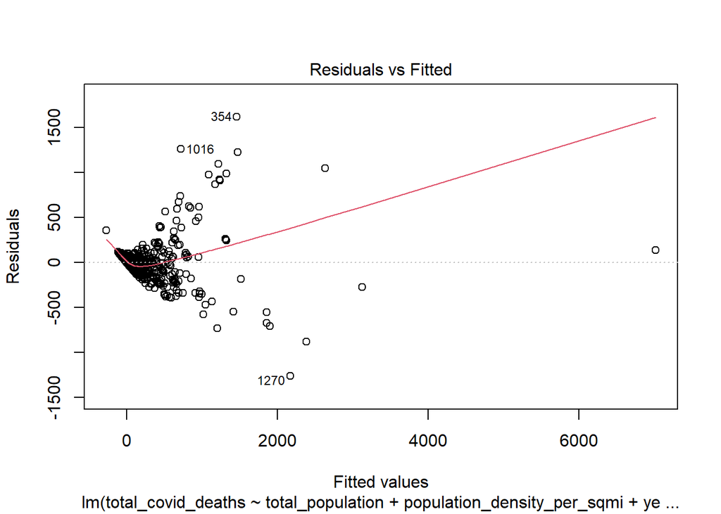

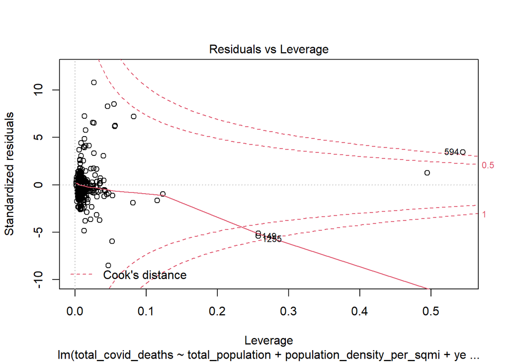

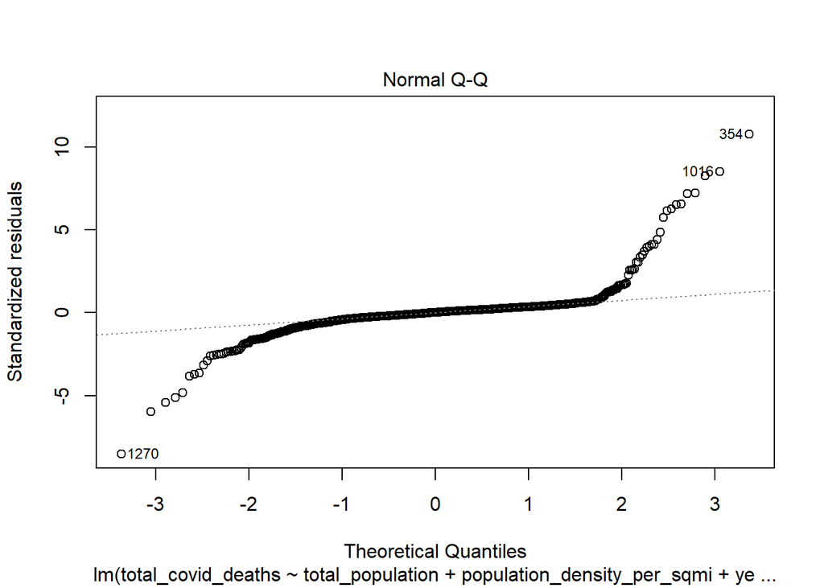

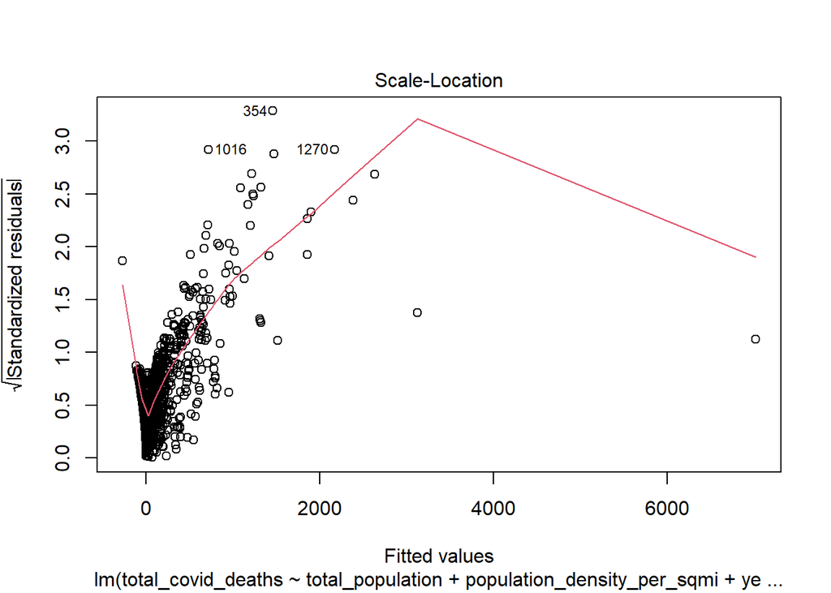

### Analysis of Model: Additional Tests on Errors

##### Shapiro-Wilk Test for normality

- Alternatives:
  - $H_0$: if p > 0.05, Error variances are normally distributed
  - $H_a$: if p < 0.05, Error variances are not normally distributed
- Conclusion:
  - Errors are not normally distributed.
  - This test confirms what we found in our visual analysis of the Normal QQ plot.

```r
shapiro.test(multi_reg_red$residuals)
```

```
##
##  Shapiro-Wilk normality test
##
## data:  multi_reg_red$residuals
## W = 0.6221, p-value < 2.2e-16
```

##### Breush-Pagan Test (with alpha = .05.): for constancy of errors

- Since visual analysis shows that the errors are not constant but seem to increase with the value of X, we are doing a Breusch-Pagan test to determine if this is infact so.

Alternatives:

- $H_0$: Error variances are constant
- $H_a$: Error variances are not constant

Decision Rule:

- If p_value > 0.05, accept $H_0$, error variances are constant
- If p_value < 0.05, reject $H_0$, error variances are not constant

Conclusion:

- p_value < 0.05
- We **reject** the null hypothesis, $H_0$. The error variances are not constant.

```r
library(lmtest)
bptest(multi_reg_red, studentize = FALSE)
```

```
##
##  Breusch-Pagan test
##
## data:  multi_reg_red
## BP = 6583.7, df = 11, p-value < 2.2e-16
```

#### General Linear Test with ANOVA : To compare both models

```r
anova(multi_reg_red, multi_reg_full)
```

```
## Analysis of Variance Table
##
## Model 1: total_covid_deaths ~ total_population + population_density_per_sqmi +
##     years_of_potential_life_lost_rate + years_of_potential_life_lost_rate +
##     income_ratio + Percent_physically_inactive + Total_serious_crimes +
##     Percent_below_poverty_level + Percent_unemployment + Total_personal_income +
##     NE + MW
## Model 2: total_covid_deaths ~ total_population + population_density_per_sqmi +
##     years_of_potential_life_lost_rate + percent_smokers + percent_adults_with_obesity +
##     food_environment_index + income_ratio + Percent_physically_inactive +
##     percent_uninsured + num_primary_care_physicians + total_covid_cases +
##     Percent_population_aged_18_34 + Percent_population_65_older +
##     Number_active._physicians + Number_hospital_beds + Total_serious_crimes +
##     Percent_highschool_graduates + Percent_bachelor_degrees +
##     Percent_below_poverty_level + Percent_unemployment + Total_personal_income +
##     NE + MW + STH + WST
##   Res.Df      RSS Df Sum of Sq      F    Pr(>F)
## 1   1325 30586971
## 2   1312 27919909 13   2667062 9.6407 < 2.2e-16 ***
## ---
## Signif. codes:  0 '***' 0.001 '**' 0.01 '*' 0.05 '.' 0.1 ' ' 1
```

```r
# critical value

t_critical =qt(1-.10/12, 1313 )
t_critical
```

```
## [1] 2.397052
```

#### Transformation on Response Variable: Box-Cox Transformation

```
## [1] 0.2363636
```

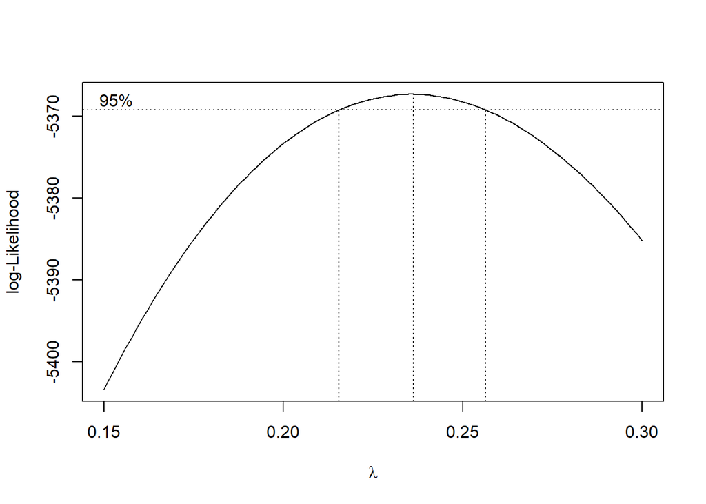

- Linear Regression on transfromed variable **total_covid_deaths**
  - Transformation has reduced the $R^2$ value and the F-statistic.

```
##
## Call:
## lm(formula = trans ~ ., data = train_df)
##
## Residuals:
##     Min      1Q  Median      3Q     Max
## -6.6261 -0.4000  0.0092  0.4721  2.5402
##
## Coefficients: (1 not defined because of singularities)
##                                        Estimate    Std. Error t value  Pr(>|t|)
## (Intercept)                        2.7343771954  0.6957476188   3.930 0.0000893
## total_population                   0.0000001295  0.0000002995   0.432   0.66555
## population_density_per_sqmi        0.0003958170  0.0000356672  11.098   < 2e-16
## years_of_potential_life_lost_rate  0.0000997540  0.0000109415   9.117   < 2e-16
## percent_smokers                   -0.0396555095  0.0091696894  -4.325 0.0000164
## percent_adults_with_obesity        0.0096747126  0.0050335141   1.922   0.05481
## food_environment_index             0.0255862332  0.0225782097   1.133   0.25733
## income_ratio                       0.0116900798  0.0358412980   0.326   0.74435
## Percent_physically_inactive       -0.0171320116  0.0052345999  -3.273   0.00109
## percent_uninsured                  0.0002252495  0.0050360476   0.045   0.96433
## num_primary_care_physicians        0.0004944641  0.0002432072   2.033   0.04224
## total_covid_cases                  0.0000087679  0.0000056417   1.554   0.12039
## total_covid_deaths                 0.0011261633  0.0001321319   8.523   < 2e-16
## Percent_population_aged_18_34      0.0025003765  0.0068838685   0.363   0.71650
## Percent_population_65_older        0.0088636871  0.0072638682   1.220   0.22259
## Number_active._physicians         -0.0000604859  0.0000577638  -1.047   0.29523
## Number_hospital_beds               0.0000149010  0.0000361791   0.412   0.68050
## Total_serious_crimes              -0.0000001522  0.0000011185  -0.136   0.89180
## Percent_highschool_graduates      -0.0189318332  0.0066619392  -2.842   0.00456
## Percent_bachelor_degrees           0.0235960736  0.0053538163   4.407 0.0000113
## Percent_below_poverty_level        0.0033040602  0.0085601294   0.386   0.69957
## Percent_unemployment               0.0006071792  0.0133886900   0.045   0.96384
## Total_personal_income             -0.0000179859  0.0000081669  -2.202   0.02782
## NE                                -0.1355289936  0.0849216181  -1.596   0.11075
## MW                                -0.0986218816  0.0734194522  -1.343   0.17942
## STH                               -0.2077434765  0.0771536066  -2.693   0.00718
## WST                                          NA            NA      NA        NA
##
## (Intercept)                       ***
## total_population
```

[output cut: 16 more lines]

```
## Percent_highschool_graduates      **
## Percent_bachelor_degrees          ***
## Percent_below_poverty_level
## Percent_unemployment
## Total_personal_income             *
## NE
## MW
## STH                               **
## WST
## ---
## Signif. codes:  0 '***' 0.001 '**' 0.01 '*' 0.05 '.' 0.1 ' ' 1
##
## Residual standard error: 0.6982 on 1311 degrees of freedom
## Multiple R-squared:  0.6396, Adjusted R-squared:  0.6327
## F-statistic: 93.07 on 25 and 1311 DF,  p-value: < 2.2e-16
```

#### Plots of Regression Model with Transformed Variable

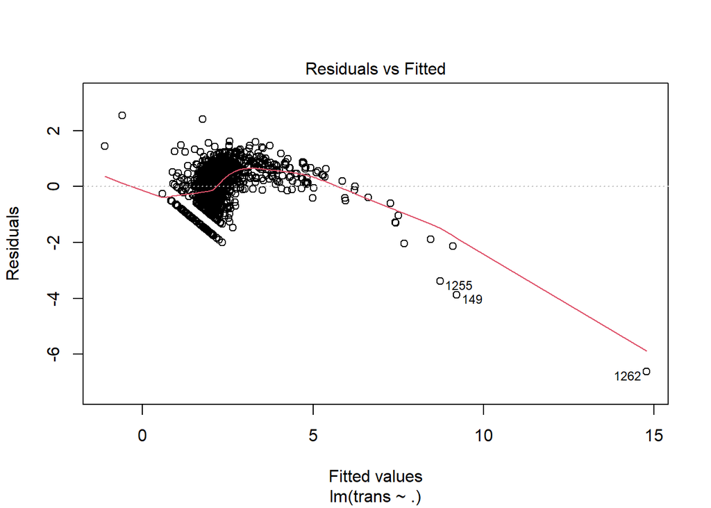

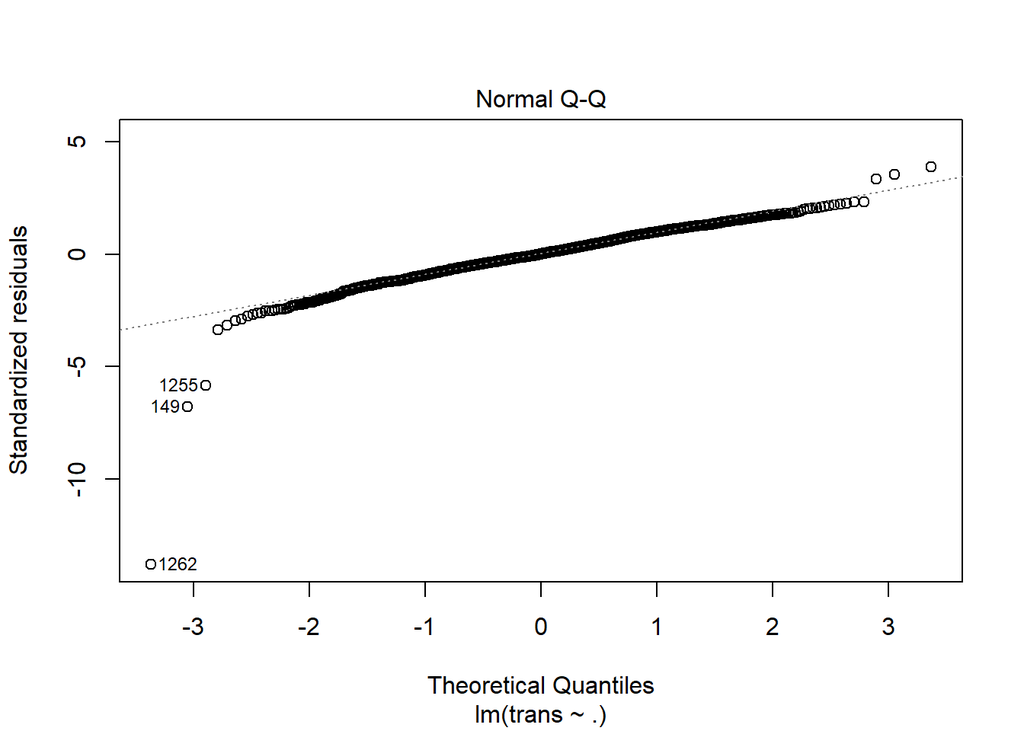

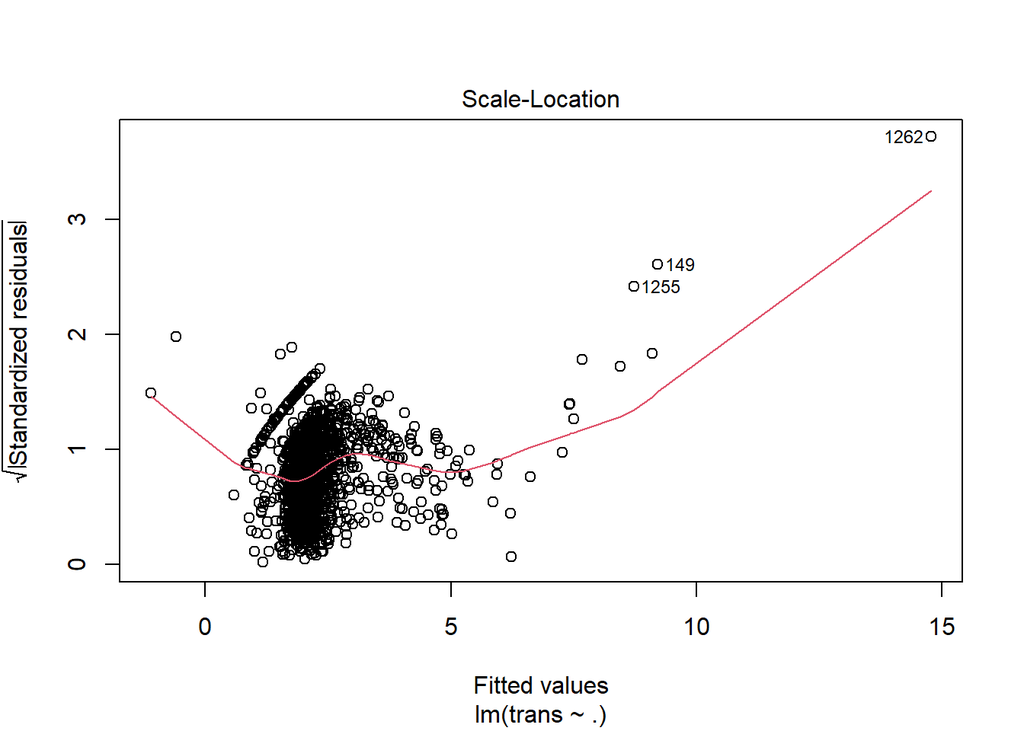

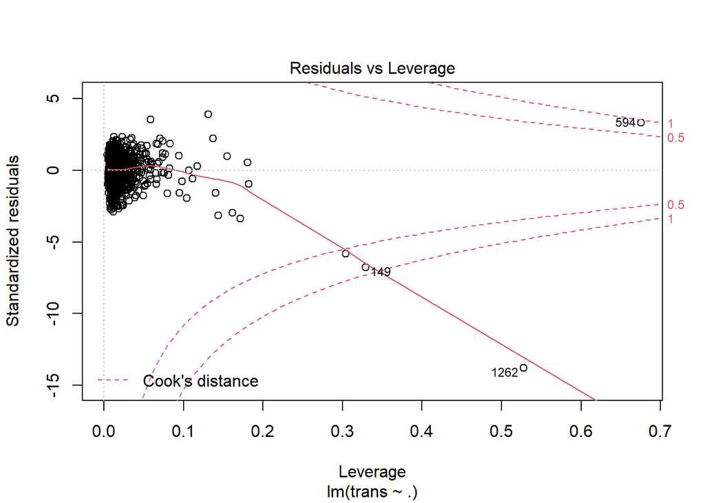

### Second Order Regression Model

- Using squared predicted variables:
  - Total Personal Income
  - Total Serious Crimes
- Removing outliers (observations: 149, 1255, 594)

```r
train_df2 <- train_df[-c(149, 1255, 594), ]
train_df2 <- train_df2[, -c(27) ]

# Centering needed.
x_crimes = (train_df2$Total_serious_crimes - mean(train_df2$Total_serious_crimes))
train_df2$x_crimes_sqr = x_crimes^2

x_income = (train_df2$Total_personal_income - mean(train_df2$Total_personal_income))
train_df2$x_income_sqr = x_income^2


multi_second_order <- lm(total_covid_deaths ~  x_crimes_sqr + x_income_sqr+ total_population + num_primary_care_physicians + Percent_population_aged_18_34 + Percent_bachelor_degrees+ Number_active._physicians + NE + percent_uninsured + total_covid_cases + years_of_potential_life_lost_rate  + Percent_physically_inactive + MW+ Percent_highschool_graduates + percent_adults_with_obesity+ population_density_per_sqmi+  food_environment_index+ Percent_unemployment +  Percent_below_poverty_level + Percent_population_65_older + WST+ STH + Number_hospital_beds, data = train_df2)


summary(multi_second_order)
```

```
##
## Call:
## lm(formula = total_covid_deaths ~ x_crimes_sqr + x_income_sqr +
##     total_population + num_primary_care_physicians + Percent_population_aged_18_34 +
##     Percent_bachelor_degrees + Number_active._physicians + NE +
##     percent_uninsured + total_covid_cases + years_of_potential_life_lost_rate +
##     Percent_physically_inactive + MW + Percent_highschool_graduates +
##     percent_adults_with_obesity + population_density_per_sqmi +
##     food_environment_index + Percent_unemployment + Percent_below_poverty_level +
##     Percent_population_65_older + WST + STH + Number_hospital_beds,
##     data = train_df2)
##
## Residuals:
##     Min      1Q  Median      3Q     Max
## -832.15  -35.89    3.86   40.18 1748.64
##
## Coefficients: (1 not defined because of singularities)
##                                            Estimate        Std. Error t value
## (Intercept)                       -291.602242308528  129.668556472700  -2.249
## x_crimes_sqr                        -0.000000003206    0.000000001455  -2.203
## x_income_sqr                         0.000000066764    0.000000021174   3.153
## total_population                     0.000178828412    0.000061537299   2.906
## num_primary_care_physicians          0.071498724141    0.049728412575   1.438
## Percent_population_aged_18_34       -1.426722585004    1.407226509227  -1.014
## Percent_bachelor_degrees             2.911555092503    1.105707272913   2.633
## Number_active._physicians            0.011092205203    0.010165861034   1.091
## NE                                  55.073344863845   12.811388936563   4.299
## percent_uninsured                    0.260078769152    1.013032086181   0.257
## total_covid_cases                    0.010861988102    0.001113259001   9.757
## years_of_potential_life_lost_rate   -0.002109022679    0.001836507259  -1.148
## Percent_physically_inactive          6.117400620614    1.010883770772   6.052
## MW                                  22.672094966584   11.444153513463   1.981
## Percent_highschool_graduates        -1.384717488152    1.349042387426  -1.026
## percent_adults_with_obesity         -1.005006518008    1.016696142233  -0.989
## population_density_per_sqmi          0.162676806674    0.009849863204  16.516
## food_environment_index              13.371721046341    4.271889319542   3.130
## Percent_unemployment                11.235904687975    2.664917265185   4.216
## Percent_below_poverty_level          2.951574347259    1.607666276548   1.836
## Percent_population_65_older          1.414834234042    1.459404623786   0.969
## WST                                  7.766065776180   15.129932545096   0.513
```

[output cut: 18 more lines]

```
## percent_adults_with_obesity             0.32309
## population_density_per_sqmi             < 2e-16 ***
## food_environment_index                  0.00179 **
## Percent_unemployment              0.00002654554 ***
## Percent_below_poverty_level             0.06659 .
## Percent_population_65_older             0.33249
## WST                                     0.60783
## STH                                          NA
## Number_hospital_beds                    0.45470
## ---
## Signif. codes:  0 '***' 0.001 '**' 0.01 '*' 0.05 '.' 0.1 ' ' 1
##
## Residual standard error: 142 on 1311 degrees of freedom
## Multiple R-squared:  0.8501, Adjusted R-squared:  0.8476
## F-statistic: 337.9 on 22 and 1311 DF,  p-value: < 2.2e-16
```

#### Plots: Residuals vs Y, Normal QQ, Error Variances, Scale-Location, Residual vs Leverage

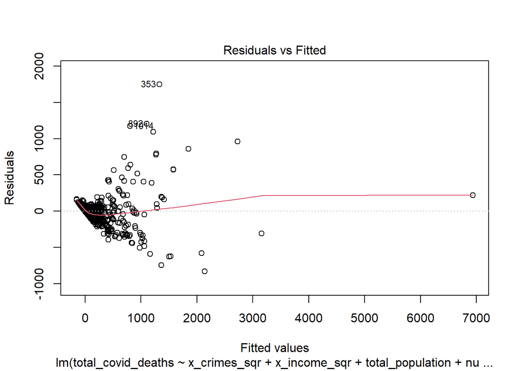

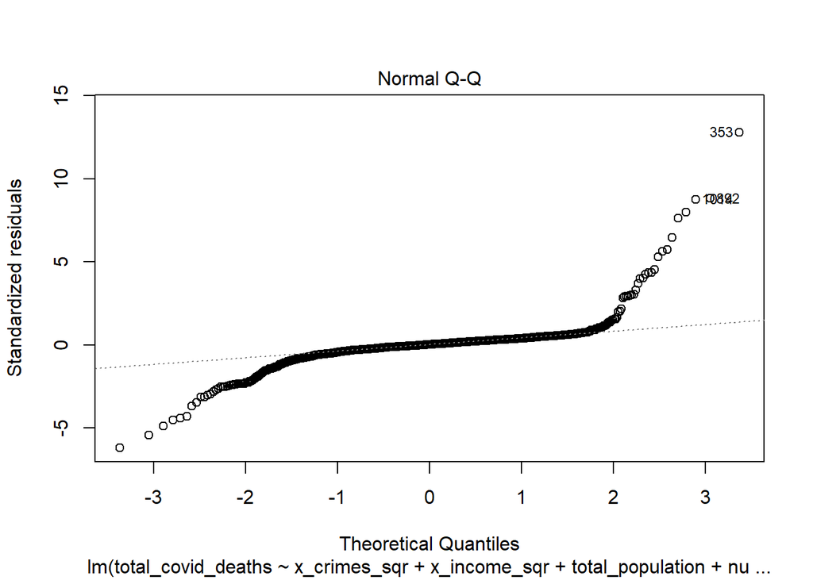

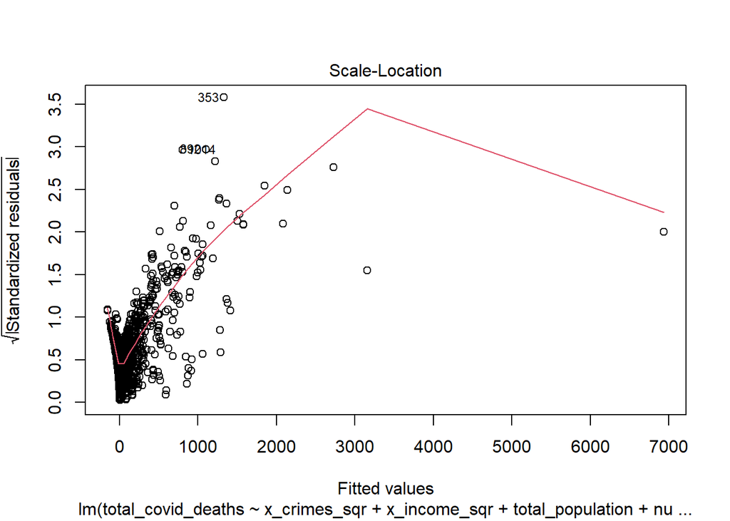

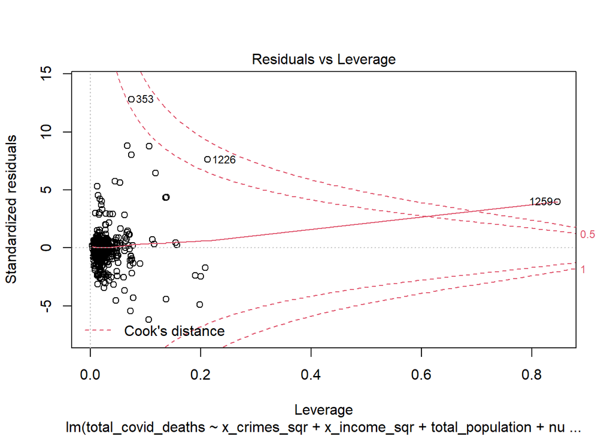

### Predict Total Covid Deaths

- Use predict() function with the full first order and second order multiple linear regression models.

#### Summary of Prediction and Model Results:

```r
pred_full <- predict(multi_reg_full, newdata =  test_df)
pred_reduced <- predict(multi_reg_red, newdata =  test_df)
pred_transf <- predict(transformed_lm, newdata = test_df)

test_df2 <- test_df[, -c(17, 22)]
x_crimes = (test_df$Total_serious_crimes - mean(test_df$Total_serious_crimes))
test_df2$x_crimes_sqr = x_crimes^2

x_income = (test_df$Total_personal_income - mean(test_df$Total_personal_income))
test_df2$x_income_sqr = x_income^2


pred_second<- predict(multi_second_order, newdata =  test_df2)

full_model <- data.frame(obs = test_df$total_covid_deaths, pred = pred_full)

reduced_model <- data.frame(obs = test_df$total_covid_deaths, pred = pred_reduced)

transf_model <- data.frame(obs = test_df$total_covid_deaths, pred = pred_transf)

second_model <- data.frame(obs = test_df$total_covid_deaths, pred = pred_second)

# Get Total Sum of Squares to get MAE and MSE and R squared values for prediction results
SST <- sum((test_df$total_covid_deaths - mean(test_df$total_covid_deaths))^2)

# first order full
MAE_first <- mean(abs(pred_full - test_df$total_covid_deaths))
MSE_first <- mean((pred_full - test_df$total_covid_deaths)^2)
SSR_first <- sum((pred_full - mean(test_df$total_covid_deaths))^2)
R_squared_full <- SSR_first/SST

#  first order Reduced
MAE_red <- mean(abs(pred_reduced - test_df$total_covid_deaths))
MSE_red <- mean((pred_reduced - test_df$total_covid_deaths)^2)
SSR_red <- sum((pred_reduced - mean(test_df$total_covid_deaths))^2)
R_squared_red <- SSR_red/SST

# Transformed Y
MAE_tranf <- mean(abs(pred_transf - test_df$total_covid_deaths))
MSE_transf <- mean((pred_transf - test_df$total_covid_deaths)^2)
SSR_transf <- sum((pred_transf - mean(test_df$total_covid_deaths))^2)
R_squared_transf <- SSR_transf/SST

# Second order full
MAE_second <- mean(abs(pred_second - test_df$total_covid_deaths))
MSE_second <- mean((pred_second - test_df$total_covid_deaths)^2)
SSR_second <- sum((pred_second - mean(test_df$total_covid_deaths))^2)
R_squared_second <- SSR_second/SST

red_rsquared <- summary(multi_reg_red)$r.squared
full_rsquared <- summary(multi_reg_full)$r.squared
transf_rsquared <- summary(transformed_lm)$r.squared
multi_rsquared <- summary(multi_second_order)$r.squared

results_df <- data.frame( Model = c("Full-first order", "Reduced-first order", "Transformed Y", "Second Order"), Prediction_Rsqrd = c (R_squared_full, R_squared_red, R_squared_transf, R_squared_second), Model_Rsqrd = c(full_rsquared, red_rsquared,transf_rsquared, multi_rsquared ) )
```

#### Results

```r
kbl(results_df) %>%
  kable_styling(bootstrap_options = c("striped", "hover", "condensed"))
```

| Model | Prediction_Rsqrd | Model_Rsqrd |
| --- | --- | --- |
| Full-first order | 0.7532813 | 0.8437041 |
| Reduced-first order | 0.7634522 | 0.8287738 |
| Transformed Y | 0.1313356 | 0.6396143 |
| Second Order | 0.9489004 | 0.8500823 |

#### Conclusion

- The second order multiple linear regression model has both the highest $R^2$ from prediction results and from the model results.
- The reduced model has a slightly higher predictability than the full model even though its model’s $R^2$ is lower.
- Transformation of the observation variable did very poorly in both prediction and model results.